# Working with spatial data available through read.abares

Adam H. Sparks

2025-12-14

This vignette demonstrates some of the functionality of {read.abares} and how to work with some of the spatial and tabular data available through {read.abares}. Please note that not all functions are demonstrated here, please refer to the function reference documentation for a full list of functionality. The worked examples here show some of the more advanced features that {read.abares} offers beyond just fetching and importing data, *e.g.*, Australian Agricultural and Grazing Industries Survey (AAGIS) spatial shapefile which can be used with tabular data from the historical estimates, the Australian Gridded Farm Data, which can be downloaded and imported using one of four types of object or the soil thickness data, which includes rich metadata.

First we need to load the {read.abares} library.

```r
library(read.abares)
```

## Working with AAGIS Regions Spatial Data

### Obtaining the AAGIS Regions Spatial Data

ABARES offers spatial data for the Australian Agricultural and Grazing Industries Survey (AAGIS) regions that can be used for mapping tabular data from the estimates, *e.g.*, `read_historical_regional_estimates()` or `read_state_estimates()`.

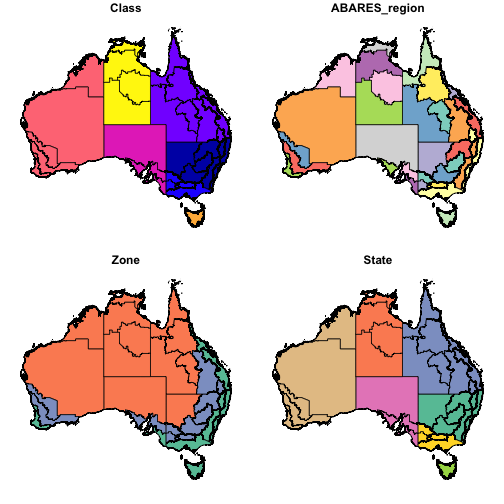

AAGIS regions shapefile

```r
aagis_regions <- read_aagis_regions()

plot(aagis_regions)
```

### Obtaining AAGIS Data by Region

{read.abares} offers functions to download the ABARES estimates based on the AAGIS results for national level, `read_historical_national_estimates()`, regional level `read_historical_regional_estimates()`, and state level `read_historical_state_estimates()` and also by performance category `read_estimates_by_performance_category()` and size category `read_estimates_by_size()`. For this example, we will use the `read_historical_regional_estimates()` function to download the AAGIS data for the regions in the AAGIS regions shapefile and join the data and visualise some of the data.

```r
aagis_region_data <- read_historical_regional_estimates()
```

[output not shown]

[output cut: 16 more lines]

[output not shown]

Filter the AAGIS region data to represent the total area cropped for the year of 2023. This will make the next few examples execute much more quickly.

```r
library(dplyr)
aagis_region_data <- filter(aagis_region_data,
                            Variable == "Total area cropped (ha)",
                            Year == 2023)
```

### Merging the AAGIS Regions Spatial Data with the AAGIS Regional Data

Using `read_aagis_regions()` and `read_historical_regional_estimates()`, we can merge the two datasets together to visualise the data. To join the data, we will use the `left_join()` function from the {dplyr} package.

```r
aagis_dat <- left_join(aagis_regions, aagis_region_data)
```

Once we’ve joined the data, we can visualise it using {ggplot2}. Here we can plot the total area cropped (ha) for all of Australia for the year 2023.

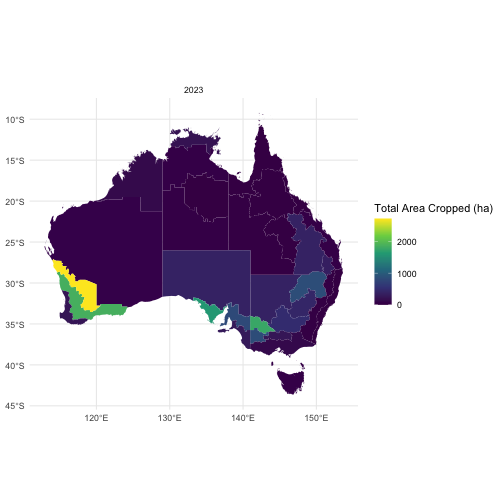

Plot of AAGIS estimated total area cropped by year and region.

```r
library(ggplot2)

ggplot(aagis_dat) +
  geom_sf(aes(fill = Value), colour = NA) +
  scale_fill_viridis_c() +
  labs(
    fill = "Total Area Cropped (ha)"
  ) +
  facet_wrap(~Year) +
  theme_minimal()
```

## Working With AGFD Data

You can download files and pipe directly into the class object that you desire for the Australian Farm Gridded Data (AGFD) data.

### Description of the Australian Farm Gridded Data

Directly from the DAFF website:

> The Australian Gridded Farm Data are a set of national scale maps containing simulated data on historical broadacre farm business outcomes including farm profitability on an 0.05-degree (approximately 5 km) grid.

> These data have been produced by ABARES as part of the ongoing [Australian Agricultural Drought Indicator](https://www.agriculture.gov.au/abares/research-topics/climate/australian-agricultural-drought-indicators-project) (AADI) project (previously known as the Drought Early Warning System Project) and were derived using ABARES [*farmpredict*](https://www.agriculture.gov.au/abares/research-topics/climate/drought/farmpredict) model, which in turn is based on ABARES [Agricultural and Grazing Industries Survey](https://www.agriculture.gov.au/abares/research-topics/surveys/farm-definitions-methods) (AAGIS) data.

> These maps provide estimates of farm business profit, revenue, costs and production by location (grid cell) and year for the period 1990-91 to 2022-23. The data do not include actual observed outcomes but rather model predicted outcomes for representative or ‘typical’ broadacre farm businesses at each location considering likely farm characteristics and prevailing weather conditions and commodity prices.

> The Australian Gridded Farm Data remain under active development, and as such should be considered experimental.

– Australian Department of Agriculture, Fisheries and Forestry.

Download and read the AGFD files as a list of {stars} objects returning only data for the year 2000.

```r
# A list of {stars} objects for the climate in year 2000
star <- read_agfd_stars(2000)
```

```
#> no 'var' specified, using farmno, R_total_hat_ha, C_total_hat_ha, FBP_fci_hat_ha, FBP_fbp_hat_ha, A_wheat_hat_ha, H_wheat_dot_hat, A_barley_hat_ha, H_barley_dot_hat, A_sorghum_hat_ha, H_sorghum_dot_hat, A_oilseeds_hat_ha, H_oilseeds_dot_hat, R_wheat_hat_ha, R_sorghum_hat_ha, R_oilseeds_hat_ha, R_…
#> other available variables:
#>  lon, lat
#> Will return stars object with 612226 cells.
#> No projection information found in nc file.
#>  Coordinate variable units found to be degrees,
#>  assuming WGS84 Lat/Lon.
```

```r
head(star[[1]])
```

```
#> stars object with 2 dimensions and 6 attributes
#> attribute(s):
#>                         Min.         1st Qu.         Median           Mean
#> farmno          15612.000000 233091.50000000 329567.0000000 324737.7187618
#> R_total_hat_ha      3.105843      7.09662085     19.7569846    169.1918352
#> C_total_hat_ha      1.282748      4.27412711      9.8605795     94.1287971
#> FBP_fci_hat_ha   -134.049904      2.86625943      9.8397018     75.0630380
#> FBP_fbp_hat_ha   -328.818624      3.42896902     12.3912337     63.5968722
#> A_wheat_hat_ha      0.000000      0.04116083      0.1126724      0.1368933
#>                        3rd Qu.           Max.   NA's
#> farmno          418508.5000000 669706.0000000 443899
#> R_total_hat_ha     161.2597086   2459.0029014 443899
#> C_total_hat_ha      92.5196069   1908.2287127 443899
#> FBP_fci_hat_ha      66.9675602   1224.9113170 443899
#> FBP_fbp_hat_ha      59.2320889   1214.8330655 443899
#> A_wheat_hat_ha       0.2099372      0.5107011 565224
#> dimension(s):
#>     from  to         refsys              values x/y
#> lon    1 886 WGS 84 (CRS84) [886] 112,...,156.2 [x]
#> lat    1 691 WGS 84 (CRS84) [691] -44.5,...,-10 [y]
```

Download and read the AGFD files as a [terra::rast](https://rspatial.github.io/terra/reference/rast.html) object.

```r
# A {terra} `rast` object
terr <- read_agfd_terra(2000)

head(terr[[1]])
```

```
#> class       : SpatRaster
#> size        : 6, 886, 41  (nrow, ncol, nlyr)
#> resolution  : 0.05, 0.05  (x, y)
#> extent      : 111.975, 156.275, -10.275, -9.975  (xmin, xmax, ymin, ymax)
#> coord. ref. : lon/lat WGS 84 (CRS84) (OGC:CRS84)
#> source(s)   : memory
#> names       : farmno, R_tot~at_ha, C_tot~at_ha, FBP_f~at_ha, FBP_f~at_ha, A_whe~at_ha, ...
#> min values  :    NaN,         NaN,         NaN,         NaN,         NaN,         NaN, ...
#> max values  :    NaN,         NaN,         NaN,         NaN,         NaN,         NaN, ...
```

Download and read the AGFD files as a list of {tidync} objects.

```r
# A list of {tidync} objects
tdnc <- read_agfd_tidync(2000)

head(tdnc[[1]])
```

```
#> $source
#> # A tibble: 1 × 2
#>   access              source
#>   <dttm>              <chr>
#> 1 2025-12-14 09:31:46 /private/var/folders/vz/txwj1tx51txgw7zv_b5c5_3m0000gn/T/…
#>
#> $axis
#> # A tibble: 84 × 3
#>     axis variable       dimension
#>    <int> <chr>              <int>
#>  1     1 lon                    0
#>  2     2 lat                    1
#>  3     3 farmno                 0
#>  4     4 farmno                 1
#>  5     5 R_total_hat_ha         0
#>  6     6 R_total_hat_ha         1
#>  7     7 C_total_hat_ha         0
#>  8     8 C_total_hat_ha         1
#>  9     9 FBP_fci_hat_ha         0
#> 10    10 FBP_fci_hat_ha         1
#> # ℹ 74 more rows
#>
#> $grid
#> # A tibble: 3 × 4
#>   grid  ndims variables         nvars
#>   <chr> <int> <list>            <int>
#> 1 D0,D1     2 <tibble [41 × 1]>    41
#> 2 D0        1 <tibble [1 × 1]>      1
#> 3 D1        1 <tibble [1 × 1]>      1
#>
#> $dimension
#> # A tibble: 2 × 8
#>      id name  length unlim coord_dim active start count
#>   <int> <chr>  <dbl> <lgl> <lgl>     <lgl>  <int> <int>
#> 1     0 lon      886 FALSE TRUE      TRUE       1   886
#> 2     1 lat      691 FALSE TRUE      TRUE       1   691
#>
#> $variable
#> # A tibble: 43 × 7
#>       id name            type      ndims natts dim_coord active
```

[output cut: 13 more lines]

```
#> $attribute
#> # A tibble: 49 × 4
#>       id name       variable       value
#>    <int> <chr>      <chr>          <named list>
#>  1     0 _FillValue lon            <dbl [1]>
#>  2     1 units      lon            <chr [1]>
#>  3     0 _FillValue lat            <dbl [1]>
#>  4     1 units      lat            <chr [1]>
#>  5     0 _FillValue farmno         <dbl [1]>
#>  6     0 _FillValue R_total_hat_ha <dbl [1]>
#>  7     0 _FillValue C_total_hat_ha <dbl [1]>
#>  8     0 _FillValue FBP_fci_hat_ha <dbl [1]>
#>  9     0 _FillValue FBP_fbp_hat_ha <dbl [1]>
#> 10     0 _FillValue A_wheat_hat_ha <dbl [1]>
#> # ℹ 39 more rows
```

Download and read the AGFD files as a {data.table} object.

```r
# A {data.table} object
dtbl <- read_agfd_dt(2000)

#Check the completeness and other metadata about the data
library(skimr)
skim(dtbl)
```

Data summary

| Name | dtbl |
| --- | --- |
| Number of rows | 168327 |
| Number of columns | 44 |
| Key | NULL |
| _______________________ |  |
| Column type frequency: |  |
| character | 1 |
| numeric | 43 |
| ________________________ |  |
| Group variables | None |

**Variable type: character**

| skim_variable | n_missing | complete_rate | min | max | empty | n_unique | whitespace |
| --- | --- | --- | --- | --- | --- | --- | --- |
| id | 0 | 1 | 26 | 26 | 0 | 1 | 0 |

**Variable type: numeric**

| skim_variable | n_missing | complete_rate | mean | sd | p0 | p25 | p50 | p75 | p100 | hist |
| --- | --- | --- | --- | --- | --- | --- | --- | --- | --- | --- |
| farmno | 0 | 1.00 | 324737.72 | 119413.06 | 15612.00 | 233091.50 | 329567.00 | 418508.50 | 669706.00 | ▂▆▇▆▁ |
| R_total_hat_ha | 0 | 1.00 | 169.19 | 303.84 | 3.11 | 7.10 | 19.76 | 161.26 | 2459.00 | ▇▁▁▁▁ |
| C_total_hat_ha | 0 | 1.00 | 94.13 | 169.85 | 1.28 | 4.27 | 9.86 | 92.52 | 1908.23 | ▇▁▁▁▁ |
| FBP_fci_hat_ha | 0 | 1.00 | 75.06 | 139.61 | -134.05 | 2.87 | 9.84 | 66.97 | 1224.91 | ▇▁▁▁▁ |
| FBP_fbp_hat_ha | 0 | 1.00 | 63.60 | 113.65 | -328.82 | 3.43 | 12.39 | 59.23 | 1214.83 | ▁▇▁▁▁ |
| A_wheat_hat_ha | 121325 | 0.28 | 0.14 | 0.12 | 0.00 | 0.04 | 0.11 | 0.21 | 0.51 | ▇▅▂▂▁ |
| H_wheat_dot_hat | 129784 | 0.23 | 2.46 | 0.92 | 0.42 | 1.69 | 2.44 | 3.12 | 5.43 | ▃▇▇▃▁ |
| A_barley_hat_ha | 121325 | 0.28 | 0.06 | 0.06 | 0.00 | 0.00 | 0.05 | 0.09 | 0.29 | ▇▃▂▁▁ |
| H_barley_dot_hat | 134701 | 0.20 | 2.41 | 0.75 | 0.03 | 1.91 | 2.43 | 2.92 | 4.98 | ▁▅▇▃▁ |
| A_sorghum_hat_ha | 152991 | 0.09 | 0.02 | 0.04 | 0.00 | 0.00 | 0.00 | 0.00 | 0.25 | ▇▁▁▁▁ |
| H_sorghum_dot_hat | 165558 | 0.02 | 3.47 | 0.99 | 1.39 | 2.67 | 3.32 | 4.24 | 6.51 | ▃▇▅▃▁ |
| A_oilseeds_hat_ha | 121325 | 0.28 | 0.05 | 0.05 | 0.00 | 0.00 | 0.02 | 0.09 | 0.30 | ▇▃▂▁▁ |
| H_oilseeds_dot_hat | 144457 | 0.14 | 1.64 | 0.47 | 0.32 | 1.34 | 1.66 | 1.98 | 3.02 | ▂▅▇▅▁ |
| R_wheat_hat_ha | 121325 | 0.28 | 122.86 | 124.40 | 0.00 | 19.52 | 79.59 | 201.29 | 894.12 | ▇▃▁▁▁ |
| R_sorghum_hat_ha | 152991 | 0.09 | 13.24 | 35.84 | 0.00 | 0.04 | 0.23 | 1.66 | 375.66 | ▇▁▁▁▁ |
| R_oilseeds_hat_ha | 121325 | 0.28 | 51.46 | 66.99 | 0.00 | 0.00 | 9.76 | 95.01 | 619.06 | ▇▁▁▁▁ |
| R_barley_hat_ha | 121325 | 0.28 | 44.12 | 56.62 | 0.00 | 0.29 | 21.32 | 63.49 | 309.55 | ▇▂▁▁▁ |
| Q_wheat_hat_ha | 121325 | 0.28 | 0.33 | 0.34 | 0.00 | 0.05 | 0.21 | 0.53 | 2.26 | ▇▃▁▁▁ |
| Q_barley_hat_ha | 121325 | 0.28 | 0.12 | 0.16 | 0.00 | 0.00 | 0.06 | 0.18 | 0.89 | ▇▂▁▁▁ |
| Q_sorghum_hat_ha | 152991 | 0.09 | 0.05 | 0.13 | 0.00 | 0.00 | 0.00 | 0.00 | 1.50 | ▇▁▁▁▁ |
| Q_oilseeds_hat_ha | 121325 | 0.28 | 0.08 | 0.10 | 0.00 | 0.00 | 0.02 | 0.15 | 0.76 | ▇▂▁▁▁ |
| S_wheat_cl_hat_ha | 121325 | 0.28 | 0.05 | 0.05 | 0.00 | 0.01 | 0.03 | 0.07 | 0.43 | ▇▂▁▁▁ |
| S_sheep_cl_hat_ha | 0 | 1.00 | 0.20 | 0.52 | 0.00 | 0.00 | 0.00 | 0.09 | 5.07 | ▇▁▁▁▁ |
| S_sheep_births_hat_ha | 0 | 1.00 | 0.14 | 0.36 | 0.00 | 0.00 | 0.00 | 0.06 | 3.90 | ▇▁▁▁▁ |
| S_sheep_deaths_hat_ha | 0 | 1.00 | 0.01 | 0.03 | 0.00 | 0.00 | 0.00 | 0.01 | 0.34 | ▇▁▁▁▁ |
| S_beef_cl_hat_ha | 0 | 1.00 | 0.07 | 0.14 | 0.00 | 0.01 | 0.02 | 0.06 | 1.87 | ▇▁▁▁▁ |
| S_beef_births_hat_ha | 0 | 1.00 | 0.03 | 0.06 | 0.00 | 0.00 | 0.01 | 0.02 | 0.75 | ▇▁▁▁▁ |
| S_beef_deaths_hat_ha | 0 | 1.00 | 0.00 | 0.00 | 0.00 | 0.00 | 0.00 | 0.00 | 0.04 | ▇▁▁▁▁ |
| Q_beef_hat_ha | 0 | 1.00 | 0.02 | 0.05 | 0.00 | 0.00 | 0.01 | 0.02 | 0.70 | ▇▁▁▁▁ |
| Q_sheep_hat_ha | 0 | 1.00 | 0.08 | 0.20 | 0.00 | 0.00 | 0.00 | 0.03 | 2.47 | ▇▁▁▁▁ |
| Q_lamb_hat_ha | 0 | 1.00 | 0.09 | 0.25 | 0.00 | 0.00 | 0.00 | 0.03 | 3.27 | ▇▁▁▁▁ |
| R_beef_hat_ha | 0 | 1.00 | 50.65 | 129.53 | 0.00 | 3.99 | 12.45 | 31.13 | 1785.92 | ▇▁▁▁▁ |
| R_sheep_hat_ha | 0 | 1.00 | 14.20 | 35.77 | 0.00 | 0.03 | 0.26 | 5.82 | 442.53 | ▇▁▁▁▁ |
| R_lamb_hat_ha | 0 | 1.00 | 18.30 | 50.75 | 0.00 | 0.00 | 0.15 | 5.33 | 645.74 | ▇▁▁▁▁ |
| C_fodder_hat_ha | 0 | 1.00 | 4.51 | 10.33 | 0.06 | 0.22 | 0.74 | 3.73 | 197.98 | ▇▁▁▁▁ |
| C_fert_hat_ha | 0 | 1.00 | 16.65 | 35.99 | 0.00 | 0.01 | 0.05 | 8.92 | 367.57 | ▇▁▁▁▁ |
| C_fuel_hat_ha | 0 | 1.00 | 5.64 | 9.81 | 0.12 | 0.35 | 0.66 | 6.04 | 110.46 | ▇▁▁▁▁ |
| C_chem_hat_ha | 0 | 1.00 | 9.27 | 21.28 | 0.00 | 0.00 | 0.02 | 4.71 | 195.40 | ▇▁▁▁▁ |
| A_total_cropped_ha | 0 | 1.00 | 0.07 | 0.16 | 0.00 | 0.00 | 0.00 | 0.03 | 0.82 | ▇▁▁▁▁ |
| FBP_pfe_hat_ha | 0 | 1.00 | 70.04 | 123.69 | -291.84 | 3.65 | 12.94 | 67.12 | 1314.10 | ▇▃▁▁▁ |
| farmland_per_cell | 0 | 1.00 | 2060.59 | 616.84 | 61.72 | 1752.29 | 2188.27 | 2463.95 | 3024.09 | ▁▁▃▇▅ |
| lon | 0 | 1.00 | 136.82 | 10.76 | 113.15 | 130.55 | 139.95 | 145.05 | 153.60 | ▃▂▃▇▅ |
| lat | 0 | 1.00 | -26.21 | 5.97 | -43.45 | -30.90 | -26.45 | -21.65 | -10.75 | ▁▆▇▆▂ |

## Working With the Soil Thickness Map

You can download the soil depth map and import it as a {stars} or [terra::rast()](https://rspatial.github.io/terra/reference/rast.html) object.

```r
ts_t <- read_topsoil_thickness_terra()
ts_s <- read_topsoil_thickness_stars()
```

For your convenience, {read.abares} re-exports [terra::plot()](https://rspatial.github.io/terra/reference/plot.html), so you can just use `plot()` with the {terra} objects in {read.abares}, by default {stars} already handles `plot` gracefully.

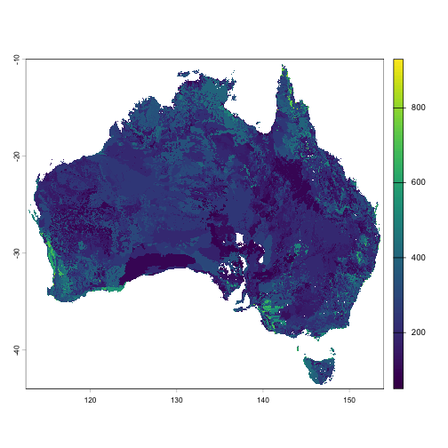

Soil Thickness for Australian areas of intensive agriculture of Layer 1 (A Horizon - top-soil) (derived from soil mapping)

```r
plot(ts_t)
```

### Soil Thickness Metadata

The topsoil thickness data object will contain the associated metadata no matter which R package you choose, {terra} or {stars}.

```r
print_topsoil_thickness_metadata()
```

```
#>
#> ── Topsoil Thickness for Australian areas of intensive agriculture of Layer 1 (A
#>
#> ── Dataset ANZLIC ID ANZCW1202000149 ──
#>
#> Custodian CSIRO, Land & Water
#>
#> Jurisdiction Australia
#>
#> Description Abstract Surface of predicted Thickness of soil layer 1 (A Horizon
#> - top-soil) surface for the intensive agricultural areas of Australia.  Data
#> modelled from area based observations made by soil agencies both State and
#> CSIRO and presented as .0.01 degree grid cells.
#>
#> Topsoils (A horizons) are defined as the surface soil layers in which organic
#> matter accumulates, and may include dominantly organic surface layers (O and P
#> horizons).
#>
#> The depth of topsoil is important because, with their higher organic matter
#> contents, topsoils (A horizon) generally have more suitable properties for
#> agriculture, including higher permeability and higher levels of soil nutrients.
#>
#> Estimates of soil depths are needed to calculate the amount of any soil
#> constituent in either volume or mass terms (bulk density is also needed) - for
#> example, the volume of water stored in the rooting zone potentially available
#> for plant use, to assess total stores of soil carbon for Greenhouse inventory
#> or to assess total stores of nutrients.
#>
#> The pattern of soil depth is strongly related to topography - the shape and
#> slope of the land.  Deeper soils are typically found in the river valleys where
#> soils accumulate on floodplains and at the footslopes of ranges (zones of
#> deposition), while soils on hillslopes (zones of erosion) tend to be shallow.
#> Map of thickness of topsoil was derived from soil map data and interpreted
#> tables of soil properties for specific soil groups.
#>
#> The quality of data on soil depth in existing soil profile datasets is
#> questionable and as the thickness of soil horizons varies locally with
#> topography, values for map units are general averages.
#>
#> The final ASRIS polygon attributed surfaces are a mosaic of all of the data
```

[output cut: 253 more lines]

```
#> Map units DECIMAL DEGREES
#>
#> Scale Scale/ resolution 1:1 000 000
#>
#> Usage Purpose Estimates of soil depths are needed to calculate the amount of
#> any soil constituent in either volume or mass terms (bulk density is also
#> needed) - for example, the volume of water stored in the rooting zone
#> potentially available for plant use, to assess total stores of soil carbon for
#> Greenhouse inventory or to assess total stores of nutrients.
#>
#> Provide indications of probable Thickness soil layer 1 in agricultural areas
#> where soil thickness testing has not been carried out
#>
#> Use Use Limitation This dataset is bound by the requirements set down by the
#> National Land & Water Resources Audit
```